# Case Study: Bellabeat

Mharie Brigham

May 2024

## Scenario:

Bellabeat is a high-tech manufacturer of health-focused products for women. They have asked for an analysis of smart device fitness data to highlight new growth opportunities for the company. The stakeholders include the Bellabeat cofounders and marketing analytics team. The products to analyze include the Bellabeat app, the Leaf wellness tracker, the Time wellness watch, the Spring water bottle, and the Bellabeat membership program.

##### Bellabeat App

Provides health data related to their activity, sleep, stress, menstrual cycle, and mindfulness habits. The app connects to Bellabeat smart wellness products

##### Leaf

Can be worn as a bracelet, necklace, or clip and tracks activity, sleep, and stress.

##### Time

Smart watch that tracks user activity, sleep, and stress.

##### Spring

Smart water bottle that tracks daily water intake.

##### Bellabeat membership

Subscription-based membership program that gives users 24/7 access to fully personalized guidance on nutrition, activity, sleep, health and beauty, and mindfulness based on their lifestyle and goals.

#### Business Task:

Identify trends in smart device usage, determine applicability to Bellabeat customer base and products, and recommend marketing strategies.

#### Dataset:

Since we have no data directly from Bellabeat, third-party data from FitBit customers will be used. Both Bellabeat and FitBit have similar products and customer bases.

Mobius. (2016). FitBit Fitness Tracker Data, Version 2. Retrieved 5.16.24 from (https://zenodo.org/records/53894#.ZAiD4XbMJPa)

##### Tools

R will be used to clean, analyze, and visualize the data for this case study for its statistical analysis power. The packages used include ‘tidyverse,’ ‘janitor,’ ‘skimr,’ ‘dplyr,’ and ‘ggforce,’

## Processing Data:

#### Libraries and Datasets:

```r
library(tidyverse)
library(lubridate)
library(janitor)
library(skimr)
library(dplyr)
library(ggforce)
dailyactivity <- read.csv('fitbit_data_v1/dailyActivity_merged.csv')
minutesleep <- read.csv('fitbit_data_v1/minuteSleep_merged.csv')
```

### Cleaning Data:

##### Cleaning for daily activity

Reviewing the first few rows:

```r
##dailyactivity
# Review data
head(dailyactivity)
```

```
##           Id ActivityDate TotalSteps TotalDistance TrackerDistance
## 1 1503960366    3/25/2016      11004          7.11            7.11
## 2 1503960366    3/26/2016      17609         11.55           11.55
## 3 1503960366    3/27/2016      12736          8.53            8.53
## 4 1503960366    3/28/2016      13231          8.93            8.93
## 5 1503960366    3/29/2016      12041          7.85            7.85
## 6 1503960366    3/30/2016      10970          7.16            7.16
##   LoggedActivitiesDistance VeryActiveDistance ModeratelyActiveDistance
## 1                        0               2.57                     0.46
## 2                        0               6.92                     0.73
## 3                        0               4.66                     0.16
## 4                        0               3.19                     0.79
## 5                        0               2.16                     1.09
## 6                        0               2.36                     0.51
##   LightActiveDistance SedentaryActiveDistance VeryActiveMinutes
## 1                4.07                       0                33
## 2                3.91                       0                89
## 3                3.71                       0                56
## 4                4.95                       0                39
## 5                4.61                       0                28
## 6                4.29                       0                30
##   FairlyActiveMinutes LightlyActiveMinutes SedentaryMinutes Calories
## 1                  12                  205              804     1819
## 2                  17                  274              588     2154
## 3                   5                  268              605     1944
## 4                  20                  224             1080     1932
## 5                  28                  243              763     1886
## 6                  13                  223             1174     1820
```

Checking the data types in this data frame:

```r
# Check data types
glimpse(dailyactivity)
```

```
## Rows: 457
## Columns: 15
## $ Id                       <dbl> 1503960366, 1503960366, 1503960366, 150396036…
## $ ActivityDate             <chr> "3/25/2016", "3/26/2016", "3/27/2016", "3/28/…
## $ TotalSteps               <int> 11004, 17609, 12736, 13231, 12041, 10970, 122…
## $ TotalDistance            <dbl> 7.11, 11.55, 8.53, 8.93, 7.85, 7.16, 7.86, 7.…
## $ TrackerDistance          <dbl> 7.11, 11.55, 8.53, 8.93, 7.85, 7.16, 7.86, 7.…
## $ LoggedActivitiesDistance <dbl> 0, 0, 0, 0, 0, 0, 0, 0, 0, 0, 0, 0, 0, 0, 0, …
## $ VeryActiveDistance       <dbl> 2.57, 6.92, 4.66, 3.19, 2.16, 2.36, 2.29, 3.3…
## $ ModeratelyActiveDistance <dbl> 0.46, 0.73, 0.16, 0.79, 1.09, 0.51, 0.49, 0.8…
## $ LightActiveDistance      <dbl> 4.07, 3.91, 3.71, 4.95, 4.61, 4.29, 5.04, 3.6…
## $ SedentaryActiveDistance  <dbl> 0.00, 0.00, 0.00, 0.00, 0.00, 0.00, 0.00, 0.0…
## $ VeryActiveMinutes        <int> 33, 89, 56, 39, 28, 30, 33, 47, 40, 15, 43, 3…
## $ FairlyActiveMinutes      <int> 12, 17, 5, 20, 28, 13, 12, 21, 11, 30, 18, 18…
## $ LightlyActiveMinutes     <int> 205, 274, 268, 224, 243, 223, 239, 200, 244, …
## $ SedentaryMinutes         <int> 804, 588, 605, 1080, 763, 1174, 820, 866, 636…
## $ Calories                 <int> 1819, 2154, 1944, 1932, 1886, 1820, 1889, 186…
```

The number of null values in this data frame:

```r
# Check null values
skim_without_charts(dailyactivity)
```

Data summary

| Name | dailyactivity |
| --- | --- |
| Number of rows | 457 |
| Number of columns | 15 |
| _______________________ |  |
| Column type frequency: |  |
| character | 1 |
| numeric | 14 |
| ________________________ |  |
| Group variables | None |

**Variable type: character**

| skim_variable | n_missing | complete_rate | min | max | empty | n_unique | whitespace |
| --- | --- | --- | --- | --- | --- | --- | --- |
| ActivityDate | 0 | 1 | 8 | 9 | 0 | 32 | 0 |

**Variable type: numeric**

| skim_variable | n_missing | complete_rate | mean | sd | p0 | p25 | p50 | p75 | p100 |
| --- | --- | --- | --- | --- | --- | --- | --- | --- | --- |
| Id | 0 | 1 | 4.628595e+09 | 2.293781e+09 | 1503960366 | 2.347168e+09 | 4.057193e+09 | 6.391747e+09 | 8.877689e+09 |
| TotalSteps | 0 | 1 | 6.546560e+03 | 5.398490e+03 | 0 | 1.988000e+03 | 5.986000e+03 | 1.019800e+04 | 2.849700e+04 |
| TotalDistance | 0 | 1 | 4.660000e+00 | 4.080000e+00 | 0 | 1.410000e+00 | 4.090000e+00 | 7.160000e+00 | 2.753000e+01 |
| TrackerDistance | 0 | 1 | 4.610000e+00 | 4.070000e+00 | 0 | 1.280000e+00 | 4.090000e+00 | 7.110000e+00 | 2.753000e+01 |
| LoggedActivitiesDistance | 0 | 1 | 1.800000e-01 | 8.500000e-01 | 0 | 0.000000e+00 | 0.000000e+00 | 0.000000e+00 | 6.730000e+00 |
| VeryActiveDistance | 0 | 1 | 1.180000e+00 | 2.490000e+00 | 0 | 0.000000e+00 | 0.000000e+00 | 1.310000e+00 | 2.192000e+01 |
| ModeratelyActiveDistance | 0 | 1 | 4.800000e-01 | 8.300000e-01 | 0 | 0.000000e+00 | 2.000000e-02 | 6.700000e-01 | 6.400000e+00 |
| LightActiveDistance | 0 | 1 | 2.890000e+00 | 2.240000e+00 | 0 | 8.700000e-01 | 2.930000e+00 | 4.460000e+00 | 1.251000e+01 |
| SedentaryActiveDistance | 0 | 1 | 0.000000e+00 | 1.000000e-02 | 0 | 0.000000e+00 | 0.000000e+00 | 0.000000e+00 | 1.000000e-01 |
| VeryActiveMinutes | 0 | 1 | 1.662000e+01 | 2.892000e+01 | 0 | 0.000000e+00 | 0.000000e+00 | 2.500000e+01 | 2.020000e+02 |
| FairlyActiveMinutes | 0 | 1 | 1.307000e+01 | 3.621000e+01 | 0 | 0.000000e+00 | 1.000000e+00 | 1.600000e+01 | 6.600000e+02 |
| LightlyActiveMinutes | 0 | 1 | 1.700700e+02 | 1.222100e+02 | 0 | 6.400000e+01 | 1.810000e+02 | 2.570000e+02 | 7.200000e+02 |
| SedentaryMinutes | 0 | 1 | 9.952800e+02 | 3.370200e+02 | 32 | 7.280000e+02 | 1.057000e+03 | 1.285000e+03 | 1.440000e+03 |
| Calories | 0 | 1 | 2.189450e+03 | 8.154800e+02 | 0 | 1.776000e+03 | 2.062000e+03 | 2.667000e+03 | 4.562000e+03 |

The number of distinct ID numbers in this data frame:

```r
# Distinct Ids
n_distinct(dailyactivity$Id)
```

```
## [1] 35
```

##### Cleaning for time asleep

Reviewing the first few rows:

```r
##minutesleep
# Review data
head(minutesleep)
```

```
##           Id                 date value       logId
## 1 1503960366 3/13/2016 2:39:30 AM     1 11114919637
## 2 1503960366 3/13/2016 2:40:30 AM     1 11114919637
## 3 1503960366 3/13/2016 2:41:30 AM     1 11114919637
## 4 1503960366 3/13/2016 2:42:30 AM     1 11114919637
## 5 1503960366 3/13/2016 2:43:30 AM     1 11114919637
## 6 1503960366 3/13/2016 2:44:30 AM     1 11114919637
```

Checking the data types in this data frame:

```r
# Check data types
glimpse(minutesleep)
```

```
## Rows: 198,559
## Columns: 4
## $ Id    <dbl> 1503960366, 1503960366, 1503960366, 1503960366, 1503960366, 1503…
## $ date  <chr> "3/13/2016 2:39:30 AM", "3/13/2016 2:40:30 AM", "3/13/2016 2:41:…
## $ value <int> 1, 1, 1, 1, 1, 1, 2, 2, 1, 1, 2, 2, 1, 1, 1, 1, 1, 1, 1, 1, 1, 1…
## $ logId <dbl> 11114919637, 11114919637, 11114919637, 11114919637, 11114919637,…
```

The number of null values in this data frame:

```r
# Check null values
skim_without_charts(minutesleep)
```

Data summary

| Name | minutesleep |
| --- | --- |
| Number of rows | 198559 |
| Number of columns | 4 |
| _______________________ |  |
| Column type frequency: |  |
| character | 1 |
| numeric | 3 |
| ________________________ |  |
| Group variables | None |

**Variable type: character**

| skim_variable | n_missing | complete_rate | min | max | empty | n_unique | whitespace |
| --- | --- | --- | --- | --- | --- | --- | --- |
| date | 0 | 1 | 19 | 21 | 0 | 54523 | 0 |

**Variable type: numeric**

| skim_variable | n_missing | complete_rate | mean | sd | p0 | p25 | p50 | p75 | p100 |
| --- | --- | --- | --- | --- | --- | --- | --- | --- | --- |
| Id | 0 | 1 | 4.824304e+09 | 2.173935e+09 | 1503960366 | 2347167796 | 4702921684 | 6775888955 | 8792009665 |
| value | 0 | 1 | 1.090000e+00 | 3.100000e-01 | 1 | 1 | 1 | 1 | 3 |
| logId | 0 | 1 | 1.124161e+10 | 7.969858e+07 | 11103653021 | 11165512026 | 11243951252 | 11310735495 | 11374876178 |

The number of distinct ID numbers in this data frame:

```r
# Distinct Ids
n_distinct(minutesleep$Id)
```

```
## [1] 23
```

### Transforming Data:

Creating a new data frame to for the number of hours slept each night:

```r
# Sleep Minutes to Hours Slept per Night by User
hoursleep<-minutesleep%>%
  mutate(datenew=as.Date(mdy_hms(date)))%>%
  mutate(minutes=1)%>%
  aggregate(minutes~datenew+Id,FUN=sum)%>%
  mutate(hours=minutes/60)
  head(hoursleep)
```

```
##      datenew         Id minutes    hours
## 1 2016-03-13 1503960366     426 7.100000
## 2 2016-03-14 1503960366     386 6.433333
## 3 2016-03-15 1503960366     335 5.583333
## 4 2016-03-16 1503960366     366 6.100000
## 5 2016-03-17 1503960366     437 7.283333
## 6 2016-03-18 1503960366     411 6.850000
```

Creating a longer data frame to order distance by activity intensity:

```r
# Distance by Intensity Level
distintense<-dailyactivity%>%
  select(Id,ActivityDate,TotalDistance,VeryActiveDistance,ModeratelyActiveDistance,LightActiveDistance)%>%
  pivot_longer(cols=c('VeryActiveDistance','ModeratelyActiveDistance','LightActiveDistance'),names_to='ActivityType',values_to='Distance')
head(distintense)
```

```
## # A tibble: 6 × 5
##           Id ActivityDate TotalDistance ActivityType             Distance
##        <dbl> <chr>                <dbl> <chr>                       <dbl>
## 1 1503960366 3/25/2016             7.11 VeryActiveDistance          2.57
## 2 1503960366 3/25/2016             7.11 ModeratelyActiveDistance    0.460
## 3 1503960366 3/25/2016             7.11 LightActiveDistance         4.07
## 4 1503960366 3/26/2016            11.6  VeryActiveDistance          6.92
## 5 1503960366 3/26/2016            11.6  ModeratelyActiveDistance    0.730
## 6 1503960366 3/26/2016            11.6  LightActiveDistance         3.91
```

Creating a new data frame for the average distance by activity level intensity:

```r
# Average total distance by average activity level
distintenseavg<-dailyactivity%>%
  group_by(Id)%>%
  mutate('AvgTotalDistance'=mean(TotalDistance),'AvgVeryActiveDistance'=mean(VeryActiveDistance),'AvgModeratelyActiveDistance'=mean(ModeratelyActiveDistance),'AvgLightActiveDistance'=mean(LightActiveDistance),'Idstr'=as.character(Id))%>%
  group_by(Idstr)%>%
  select(Idstr,AvgVeryActiveDistance,AvgModeratelyActiveDistance,AvgLightActiveDistance)%>%
  distinct()%>%
  pivot_longer(cols=c('AvgVeryActiveDistance','AvgModeratelyActiveDistance','AvgLightActiveDistance'),names_to='ActivityType',values_to='Distance')
```

Creating a new frame for the average time spent at each activity level intensity:

```r
# Average total activity intensity minutes
minintenseavg<-dailyactivity%>%
  mutate('AvgSedentaryMinutes'=mean(SedentaryMinutes),'AvgVeryActiveMinutes'=mean(VeryActiveMinutes),'AvgFairlyActiveMinutes'=mean(FairlyActiveMinutes),'AvgLightlyActiveMinutes'=mean(LightlyActiveMinutes))%>%
  select(AvgSedentaryMinutes,AvgVeryActiveMinutes,AvgFairlyActiveMinutes,AvgLightlyActiveMinutes)%>%
  distinct()%>%
  pivot_longer(cols=c('AvgVeryActiveMinutes','AvgFairlyActiveMinutes','AvgLightlyActiveMinutes','AvgSedentaryMinutes'),names_to='ActivityType',values_to='Minutes')%>%
  mutate(Minutes=round(Minutes,digits=2))
```

Creating a new frame to merge hours slept per night with daily activity:

```r
# Merging sleep hours and daily activity - remove Id's without sleep data
dailyactivitynewdate <- dailyactivity%>%
  mutate(datenew=as.Date(mdy(ActivityDate)))
combineddata <- merge(hoursleep,dailyactivitynewdate, by=c('Id','datenew'))%>%
  select(-ActivityDate)
```

### Summary Statistics:

```r
dailyactivity%>%
  select(TotalSteps,TotalDistance,SedentaryMinutes)%>%
  summary()
```

```
##    TotalSteps    TotalDistance    SedentaryMinutes
##  Min.   :    0   Min.   : 0.000   Min.   :  32.0
##  1st Qu.: 1988   1st Qu.: 1.410   1st Qu.: 728.0
##  Median : 5986   Median : 4.090   Median :1057.0
##  Mean   : 6547   Mean   : 4.664   Mean   : 995.3
##  3rd Qu.:10198   3rd Qu.: 7.160   3rd Qu.:1285.0
##  Max.   :28497   Max.   :27.530   Max.   :1440.0
```

```r
hoursleep%>%
  select(minutes, hours)%>%
  summary()
```

```
##     minutes          hours
##  Min.   :  6.0   Min.   : 0.100
##  1st Qu.:365.0   1st Qu.: 6.083
##  Median :450.0   Median : 7.500
##  Mean   :425.2   Mean   : 7.086
##  3rd Qu.:521.5   3rd Qu.: 8.692
##  Max.   :959.0   Max.   :15.983
```

This gives some basic information about the average steps people are walking per day, the average total distance they are walking, and the average number of minutes they spend sedentary. According to FitBit’s user forums, when the FitBit is not worn it defaults to 1440 sedentary minutes. Additionally, users report overlap with their sleep time and their sedentary minutes.

## Correlations and Visualizations:

### Total Steps v. Sedentary Minutes

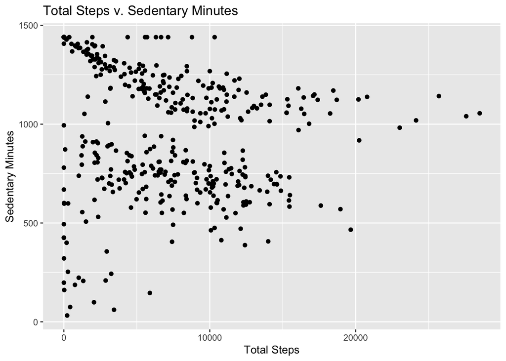

```r
ggplot(dailyactivity)+
  geom_point(aes(x=TotalSteps, y=SedentaryMinutes))+
  ggtitle("Total Steps v. Sedentary Minutes")+
  xlab("Total Steps")+
  ylab("Sedentary Minutes")
```

```r
# Correlation Test
cor.test(dailyactivity$TotalSteps,dailyactivity$SedentaryMinutes, method=c('pearson'))
```

```
##
##  Pearson's product-moment correlation
##
## data:  dailyactivity$TotalSteps and dailyactivity$SedentaryMinutes
## t = -6.3485, df = 455, p-value = 5.267e-10
## alternative hypothesis: true correlation is not equal to 0
## 95 percent confidence interval:
##  -0.3673722 -0.1987306
## sample estimates:
##        cor
## -0.2852577
```

There is a significant negative correlation between sedentary minutes and total steps. The less minutes spent sedentary, the more steps taken per day.

### Activity Intensity Breakdown

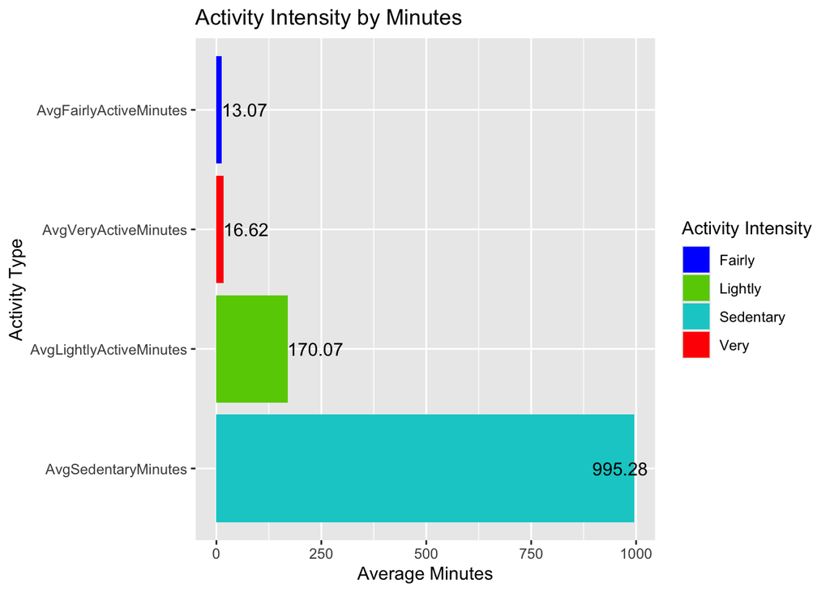

```r
ggplot()+
  xlab('Activity Type')+
  ylab('Average Minutes')+
  ggtitle('Activity Intensity by Minutes')+
  geom_col(data=minintenseavg,mapping=aes(x=fct_rev(fct_reorder(ActivityType,Minutes)),y=Minutes, fill=ActivityType))+
  scale_fill_manual(name='Activity Intensity',values=c('blue','chartreuse3','cyan3','red'),labels=c('Fairly','Lightly','Sedentary','Very'))+
  geom_text(data=minintenseavg, mapping=aes(x=fct_rev(fct_reorder(ActivityType,Minutes)), y=Minutes, label=Minutes), hjust=c(0,0,0,.75))+
  coord_flip()
```

### Active Minutes v. Total Calories

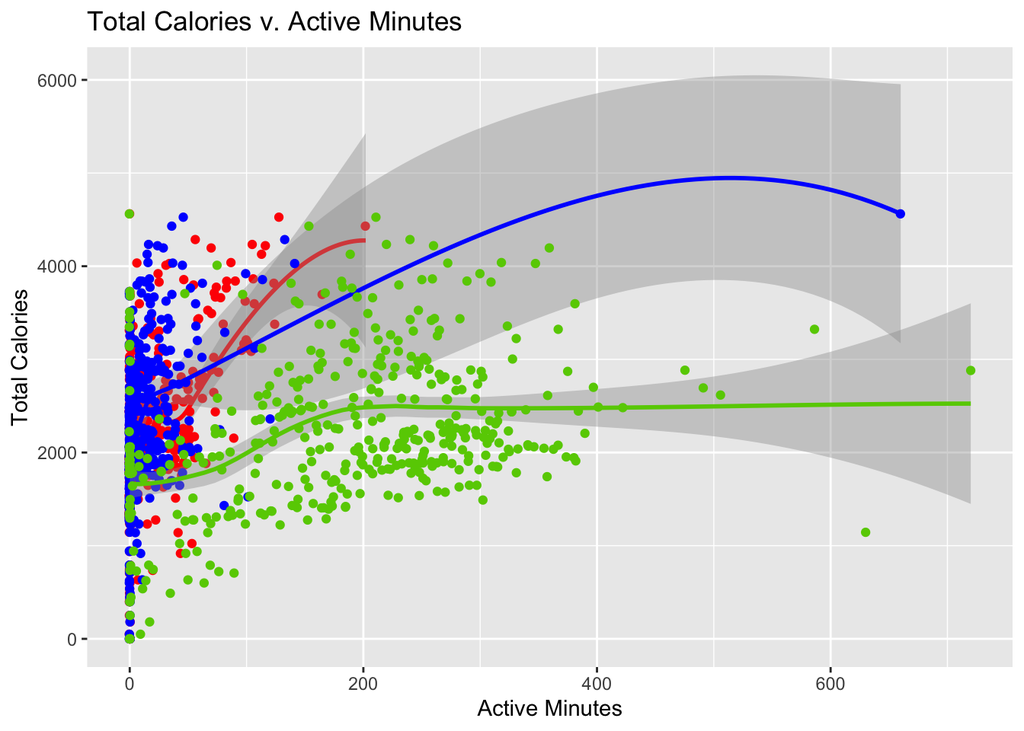

```r
ggplot(dailyactivity)+
  geom_smooth(aes(x=VeryActiveMinutes, y=Calories), color='red')+
  geom_jitter(aes(x=VeryActiveMinutes, y=Calories), color='red')+
  geom_smooth(aes(x=FairlyActiveMinutes, y=Calories), color='blue')+
  geom_jitter(aes(x=FairlyActiveMinutes, y=Calories), color='blue')+
  geom_smooth(aes(x=LightlyActiveMinutes, y=Calories), color='chartreuse3')+
  geom_jitter(aes(x=LightlyActiveMinutes, y=Calories), color='chartreuse3')+
  scale_color_discrete(name='Activity Level', labels=c('Fairly','Very','Lightly'))+
  ggtitle("Total Calories v. Active Minutes")+
  ylab("Total Calories")+
  xlab('Active Minutes')
```

```r
# Correlation Test
cor.test(dailyactivity$VeryActiveMinutes,dailyactivity$Calories, method=c('pearson'))
```

```
##
##  Pearson's product-moment correlation
##
## data:  dailyactivity$VeryActiveMinutes and dailyactivity$Calories
## t = 12.948, df = 455, p-value < 2.2e-16
## alternative hypothesis: true correlation is not equal to 0
## 95 percent confidence interval:
##  0.4485271 0.5828883
## sample estimates:
##       cor
## 0.5189053
```

```r
cor.test(dailyactivity$FairlyActiveMinutes,dailyactivity$Calories, method=c('pearson'))
```

```
##
##  Pearson's product-moment correlation
##
## data:  dailyactivity$FairlyActiveMinutes and dailyactivity$Calories
## t = 7.5725, df = 455, p-value = 2.058e-13
## alternative hypothesis: true correlation is not equal to 0
## 95 percent confidence interval:
##  0.2505107 0.4135856
## sample estimates:
##       cor
## 0.3345503
```

```r
cor.test(dailyactivity$LightlyActiveMinutes,dailyactivity$Calories, method=c('pearson'))
```

```
##
##  Pearson's product-moment correlation
##
## data:  dailyactivity$LightlyActiveMinutes and dailyactivity$Calories
## t = 8.689, df = 455, p-value < 2.2e-16
## alternative hypothesis: true correlation is not equal to 0
## 95 percent confidence interval:
##  0.2957568 0.4532909
## sample estimates:
##       cor
## 0.3772495
```

### Total Distance v. Total Calories

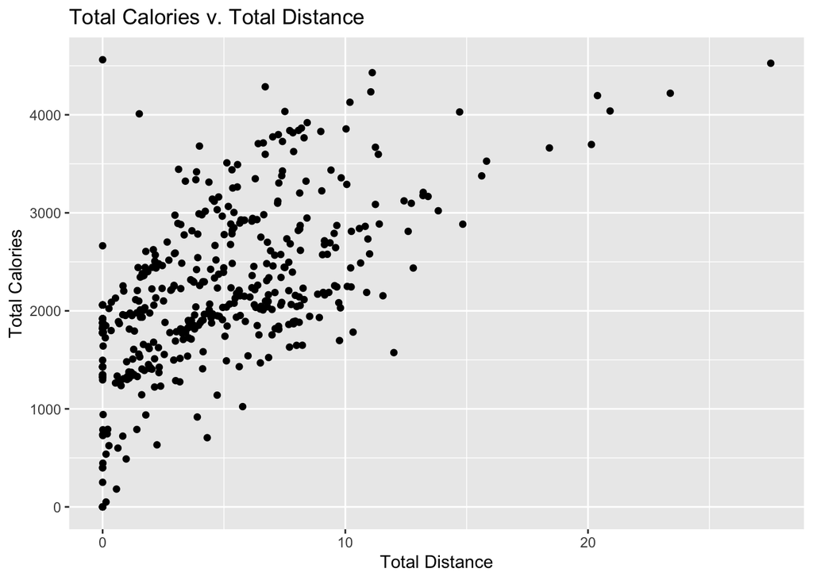

```r
ggplot(dailyactivity)+
  geom_point(aes(x=TotalDistance, y=Calories))+
  ggtitle("Total Calories v. Total Distance")+
  xlab("Total Distance")+
  ylab("Total Calories")
```

```r
# Correlation Test
cor.test(dailyactivity$TotalDistance,dailyactivity$Calories, method=c('pearson'))
```

```
##
##  Pearson's product-moment correlation
##
## data:  dailyactivity$TotalDistance and dailyactivity$Calories
## t = 16.578, df = 455, p-value < 2.2e-16
## alternative hypothesis: true correlation is not equal to 0
## 95 percent confidence interval:
##  0.5530498 0.6677856
## sample estimates:
##       cor
## 0.6136468
```

There is a significant positive correlation between total distance and calories burned. The greater distance traveled, the more calories burned.

### Total Distance by Activity Level

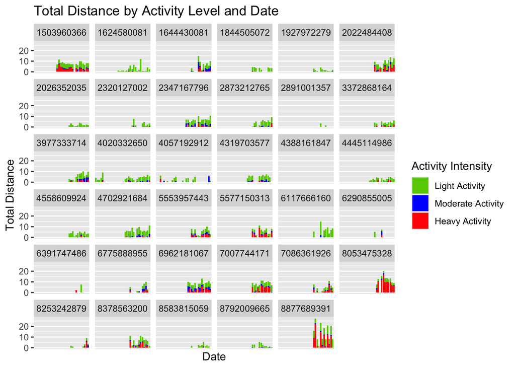

```r
# Breakdown of total distance by activity level; broken up by ID number
ggplot(distintense,mapping=aes(x=ActivityDate,y=Distance,fill=ActivityType))+
  geom_col()+
  scale_fill_manual('Activity Intensity',labels=c('Light Activity','Moderate Activity','Heavy Activity'),values=c(LightActiveDistance='chartreuse3',ModeratelyActiveDistance='blue',VeryActiveDistance='red'))+
  facet_wrap(~Id)+
  ggtitle('Total Distance by Activity Level and Date')+
  xlab('Date')+
  ylab('Total Distance')+
  scale_x_discrete(breaks=2)
```

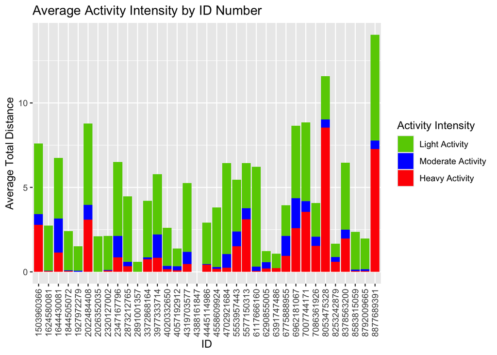

```r
# Average total distance by activity level; broken up by ID number
ggplot(distintenseavg,mapping=aes(x=Idstr,y=Distance,fill=ActivityType))+
  geom_col()+
  scale_fill_manual('Activity Intensity',labels=c('Light Activity','Moderate Activity','Heavy Activity'),values=c(AvgLightActiveDistance='chartreuse3',AvgModeratelyActiveDistance='blue',AvgVeryActiveDistance='red'))+
  xlab('ID')+
  ylab('Average Total Distance')+
  ggtitle('Average Activity Intensity by ID Number')+
  theme(axis.text.x=element_text(angle=90,vjust=.5,hjust=1))
```

These graphs exhibit each ID number’s average total daily distance and the distribution between activity intensity. These graphs indicate that the majority of users’ total daily distance are due to light activity.